# tidyplot: An R package with diversy themes and colors for biological data visualization

## Introduction

Here we developed [`tidyplot`](https://github.com/hmutpw/tidyplot) to make the data visualization easier and better. In this package, we included several commonly used themes in `ggplot2` and a large number of color combinations for biological data visualization. We’ll keep updating the themes and color combinations in our package.

### 1. Installation

The dependent packages:`graphics`, `ggplot2` and `RColorBrewer` should be installed first.

```r
#install.packages("devtools")
devtools::install_github("hmutpw/tidyplot")
```

```
These packages have more recent versions available.
It is recommended to update all of them.
Which would you like to update?

1: All                           2: CRAN packages only
3: None
4: cli    (3.6.0 -> 3.6.1) [CRAN]
5: vctrs  (0.5.2 -> 0.6.1) [CRAN]
6: tibble (3.1.8 -> 3.2.1) [CRAN]
```

```r
3
```

[output not shown]

```r
library(tidyplot)
```

### 2. Instructions for colors

#### 2.1 Colors in `tidyplot` package

The `tidyplot` package includes 19 types of sequential colors with 10 different brightness. The original colors were downloaded from [material design colors](https://www.materialpalette.com/colors). Besides, we also included the colors in `RColorBrewer` package.

##### 2.1.1. To browser all the colors in `tidyplot` package:

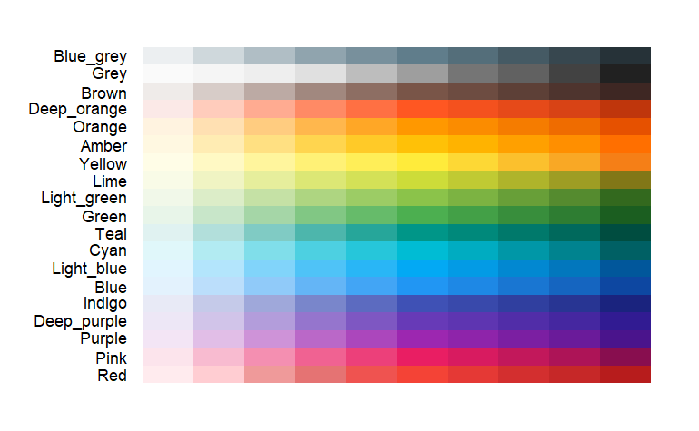

```r
display.color.all(type = "material")
```

##### 2.1.2. To browser all colors from `RColorBrewer` package:

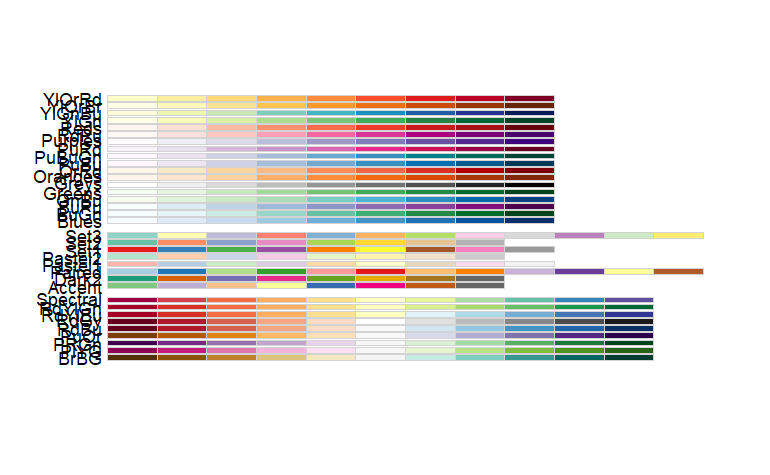

```r
library(RColorBrewer)
display.brewer.all()
```

##### 2.1.3. To browser combination of several beautiful colors in `tidyplot` package:

In `tidyplot` package, we designed some combinations for specific application situation, such as, embryonic stem cell development. You can directly using these combinations to visualize your data.

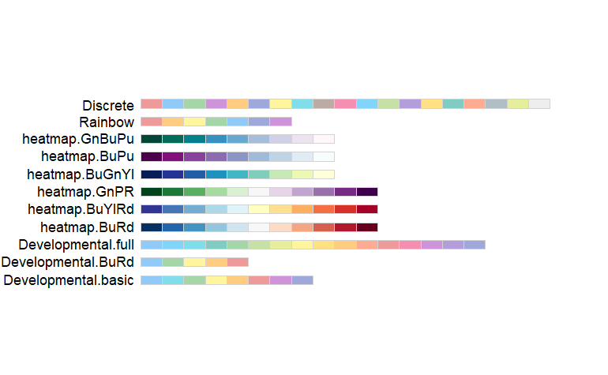

```r
display.color.all(type = "material.set")
```

To get the color code for above combinations:

```r
dev_basic <- material.color.set(name = "Developmental.basic")
dev_basic
```

```
[1] "#90CAF9" "#80DEEA" "#A5D6A7" "#FFF59D" "#FFCC80" "#EF9A9A" "#CE93D8" "#9FA8DA"
```

If you have other creative combinations, please let me known, and I’ll be happy to add into out package.

#### 2.2 Get the colors from `tidyplot` package

##### 2.2.1 get colors with different brightness

If you are considering using one type of color to visualize the intensity change, e.g. heatmaps with values between 0 to 1. you can get 19 types of colors from `tidyplot` with up to 10 different brightness. For example, you can get 6 gradient red colors:

```r
Reds <- material.colors(name = "Red",n = 6)
Reds
```

```
[1] "#FFEBEE" "#FFCDD2" "#EF9A9A" "#E57373" "#EF5350" "#F44336"
```

To visualize the above colors:

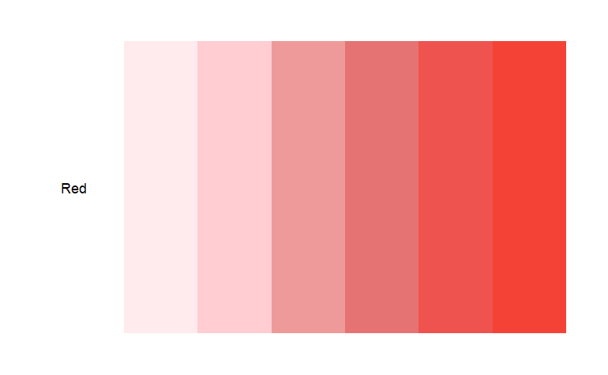

```r
display.color(colors = Reds, color_name = "Red")
```

##### 2.2.2 get colors from `RColorBrewer` package

Here, we can get colors from `RColorBrewer` package by using the function `brewer.colors()`:

```r
RdBu <- brewer.colors(name = 'RdBu',n = 11)
RdBu
```

```
 [1] "#67001F" "#B2182B" "#D6604D" "#F4A582" "#FDDBC7" "#F7F7F7" "#D1E5F0" "#92C5DE" "#4393C3" "#2166AC" "#053061"
```

To visualize the above colors:

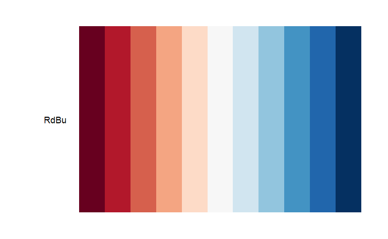

```r
display.color(colors = RdBu, color_name = "RdBu")
```

##### 2.2.3 get specific numbers of colors

The above gradient colors may not enough to visualize heatmaps. We can use `adjust.color.number()` function to expand or shrink our color to an specific number:

```r
RdBu100 <- adjust.color.number(color = RdBu,n = 100)
RdBu100
```

```
  [1] "#67001F" "#6E0220" "#760421" "#7D0722" "#850923" "#8C0C25" "#940E26" "#9C1027" "#A31328" "#AB1529" "#B2182B" "#B6202E" "#B92732" "#BD2E35" "#C03539"
 [16] "#C43D3C" "#C8443F" "#CB4B43" "#CF5246" "#D35A4A" "#D6614E" "#D96853" "#DC6F58" "#DF765E" "#E27D63" "#E58468" "#E88B6E" "#EB9273" "#EE9978" "#F1A07E"
 [31] "#F4A684" "#F5AC8B" "#F6B192" "#F7B799" "#F7BC9F" "#F8C1A6" "#F9C7AD" "#FACCB4" "#FBD2BB" "#FCD7C2" "#FCDCC8" "#FCDECD" "#FBE1D2" "#FAE4D7" "#FAE7DC"
 [46] "#F9EAE1" "#F9EDE6" "#F8EFEA" "#F7F2EF" "#F7F5F4" "#F5F6F6" "#F1F4F5" "#EDF2F5" "#E9F0F4" "#E5EEF3" "#E1EDF3" "#DEEBF2" "#DAE9F1" "#D6E7F0" "#D2E5F0"
 [61] "#CDE3EE" "#C6DFED" "#C0DCEB" "#BAD9E9" "#B3D6E7" "#ADD2E5" "#A7CFE4" "#A0CCE2" "#9AC9E0" "#93C5DE" "#8CC1DC" "#84BCD9" "#7CB7D6" "#74B2D3" "#6CADD1"
 [76] "#64A8CE" "#5CA3CB" "#549EC9" "#4C99C6" "#4494C3" "#408FC1" "#3C8ABE" "#3986BC" "#3581BA" "#327DB7" "#2F78B5" "#2B74B3" "#286FB0" "#246AAE" "#2166AC"
 [91] "#1E61A5" "#1B5B9D" "#185696" "#15508E" "#134B86" "#10457F" "#0D4077" "#0A3A70" "#073568" "#053061"
```

Then, visualize them:

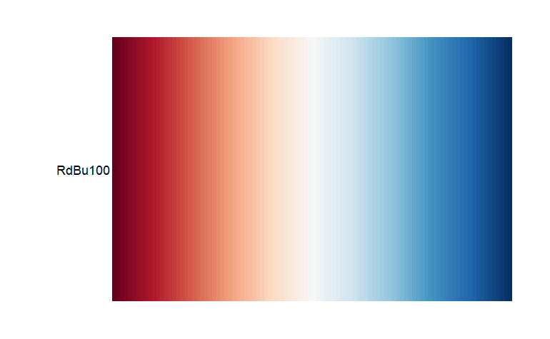

```r
display.color(colors = RdBu100, color_name = "RdBu100")
```

#### 2.3 get all colors you wanted from `tidyplot`

All the colors in `tidyplot` were deposited in `tidyplot::materialColorBrewer`, you can download the color matrix for your own design.

### 3. Instructions for themes in `ggplot2`